# Inferencia causal

De la predicción al efecto

Miguel Conde

2025-02-07

# Panorama actual de la inferencia causal

## Datos experimentales

- Proceden de estudios donde el investigador controla explícitamente la asignación del tratamiento mediante la aleatorización.
- **Ventaja**: asegura que las variables observadas y no observadas estén balanceadas entre grupos, facilitando la inferencia causal directa.
- Ejemplo: Ensayo clínico controlado, test A/B en marketing digital.

## Experimentos naturales

- Eventos externos al investigador generan una asignación casi aleatoria del tratamiento.
- Ejemplos clásicos: loterías, cambios regulatorios repentinos, reformas políticas o económicas inesperadas.

## Datos observacionales

- La asignación del tratamiento no está controlada por el investigador, por lo que existen sesgos (confounding) debido a variables confundidoras.
- Ejemplo: estudio de la relación entre fumar y cáncer usando registros médicos, efectos del consumo de un alimento en la salud en datos históricos.

## ¿Qué es un experimento randomizado?

- Es un experimento en el que la asignación al grupo de tratamiento o control se realiza mediante un proceso aleatorio.
- Esto asegura la independencia estadística del tratamiento respecto a otras variables que podrían sesgar el análisis.
- La randomización garantiza comparabilidad entre grupos, permitiendo atribuir causalmente las diferencias observadas al tratamiento.

## Métodos para datos experimentales

- **Diferencias en diferencias (Diff-in-Diff)**:
  - Compara la evolución temporal del resultado en grupos tratados y no tratados.
  - Adecuado cuando la asignación del tratamiento varía en el tiempo.
- **Grupos sintéticos de control (Synthetic Control)**:
  - Construye un grupo control artificial combinando unidades no tratadas para simular lo que habría ocurrido sin tratamiento.
  - Útil cuando hay pocos individuos tratados y se necesita un control específico y detallado.

## Conclusiones

- Los métodos experimentales permiten una inferencia causal más robusta.
- Los datos observacionales requieren métodos adicionales y supuestos claramente explicitados: **los datos *solos* no bastan para inferir causalidad**.

**¿Qué métodos existen para inferir causalidad en datos observacionales?**

# Motivación

## Clientes en riesgo de fuga

Imagina que trabajamos en una empresa que proporciona algún tipo de suministro básico a los hogares. Cuando se detecta un cliente insatisfecho, como puede estar en riesgo de fuga, se le pasa a una unidad especial de Atención al Cliente, la Unidad de Recuperación. En función de una serie de variables socio-economico-culturales y del historico del cliente se decide si aplicarle una estrategia de recuperación o no. En algunos casos la intervención tiene éxito y en otras no.

**¿Cómo saber si esta estrategia funciona?** (NOTEBOOK mock data, NOTEBOOK EDA)

**Variables disponibles**

- Sociodemográficas: edad, sexo, nivel educativo, ingresos, etc.
- Geográficas y de contexto: región, presencia de competidores.
- Relación con la empresa: antigüedad, tipo de contrato, etc.
- Insatisfacción: flag de insatisfacción, *score* de riesgo.
- Tratamiento: si recibió le intervención de la Unidad de Recuperación.
- Resultado: si se quedó o se fue.

## ¿Cómo lo harías tú?

Dado lo que has visto del dataset y sabiendo que la asignación de la intervención no fue aleatoria, ¿qué enfoque propondrías para estimar de forma confiable el efecto causal de la intervención en la retención del cliente?

1. Utilizar únicamente a los clientes que recibieron la intervención, evaluando cuántos se quedaron frente a cuántos se fueron.
2. Comparar directamente clientes intervenidos con clientes no intervenidos, sin controlar por otras variables.
3. Realizar una comparación ajustando (controlando) por variables importantes como edad, ingresos o riesgo de fuga.
4. Buscar o crear un grupo comparable de clientes que no recibieron la intervención y compararlo con el grupo intervenido.
5. No se puede estimar el efecto causal de forma fiable con estos datos.

# Un ejemplo más sencillo

## Helados y muertes por ahogamiento

**Datos anuales**

| Helados vendidos ($\times{10}^6$) | Muertes por ahogamiento |
| --- | --- |
| 200 | 10 |
| 250 | 15 |
| 300 | 20 |
| 350 | 25 |
| … | … |

La correlación entre ambas variables es $0.67$ (NOTEBOOK mock data, NOTEBOOK EDA).

**¿Qué preguntas podemos responder con los datos de la tabla?**

- ¿Cuántos ahogamientos esperamos en función del número de helados vendidos? Y ¿viceversa?
- Con 200 M de helados vendidos se produjeron 10 muertes. ¿Cuánto efecto tuvo el número de helados en el de muertes?
- Con 250 M de helados vendidos se produjeron 15 ahogamientos. ¿Cuántos esperamos si vendemos el doble de helados? Y ¿si vendemos la mitad?
- Con 300 millones de helados vendidos hubo 20 muertes ¿Cuántas hubiera habido si hubiéramos vendido 400 M de helados?

## Tipos de preguntas - Asociación

*Seeing* **- Observación / Correlación**

Este nivel se basa únicamente en correlaciones y patrones en los datos sin inferir causalidad. Aquí, utilizamos estadísticas descriptivas y modelos de predicción (correlación, predicción, forecasting…).

- *¿Cuántas muertes por ahogamiento esperamos en función del número de helados vendidos? (predicción). Y ¿viceversa?*

## Tipos de preguntas - Intervención

*Doing* **- Experimentos / Manipulación**

Aquí nos preguntamos qué pasaría si intervenimos activamente en el sistema, modificando una variable de manera externa.

- *Con 250 M de helados vendidos se produjeron 15 muertes. ¿Cuántas esperamos si vendemos el doble de helados? Y ¿si vendemos la mitad?*

## Tipos de preguntas - Contrafactuales

*Imagining* **- “¿Qué hubiera pasado si…?”**

Este nivel implica responder preguntas hipotéticas sobre escenarios alternativos que no ocurrieron en la realidad.

- *Con 200 M de helados vendidos se produjeron 10 muertes. ¿Cuánto efecto (causal) tuvo el número de helados vendidos en el de ahogamientos?*
- *Con 300 M de helados vendidos hubo 20 muertas¿Cuántos hubiera habido si hubiéramos vendido 400 M de helados?*

## ¿Cuál es el modelo CAUSAL implícito en nuestra mente?

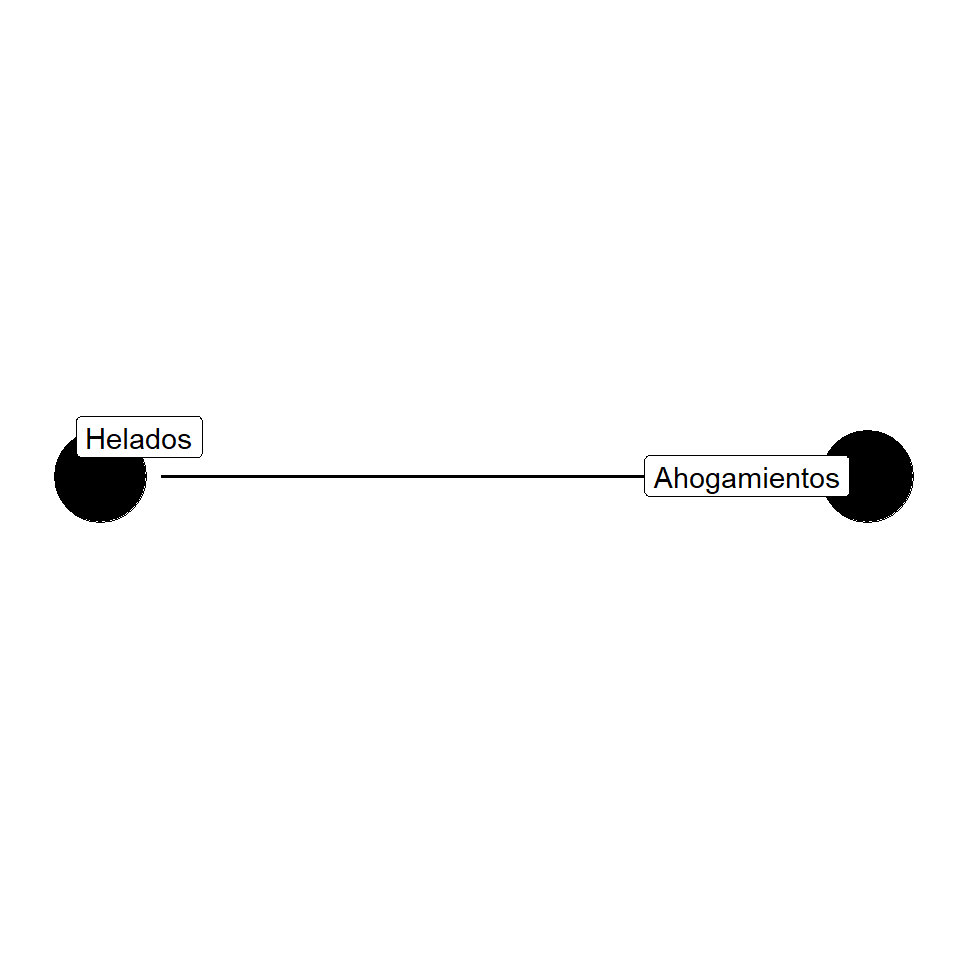

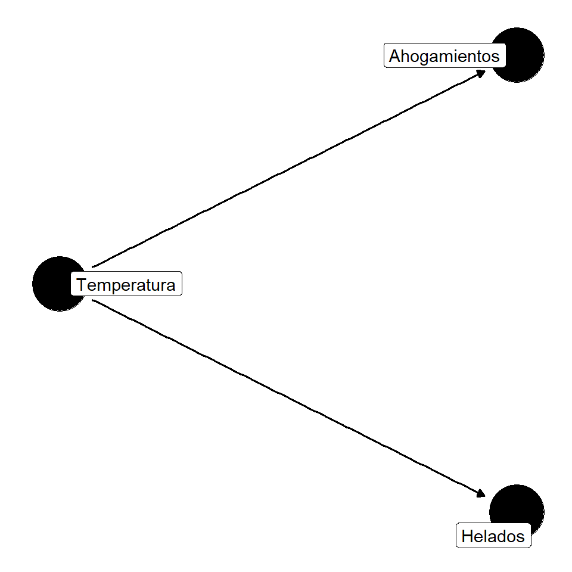

## Qué pasa si las cosas se complican

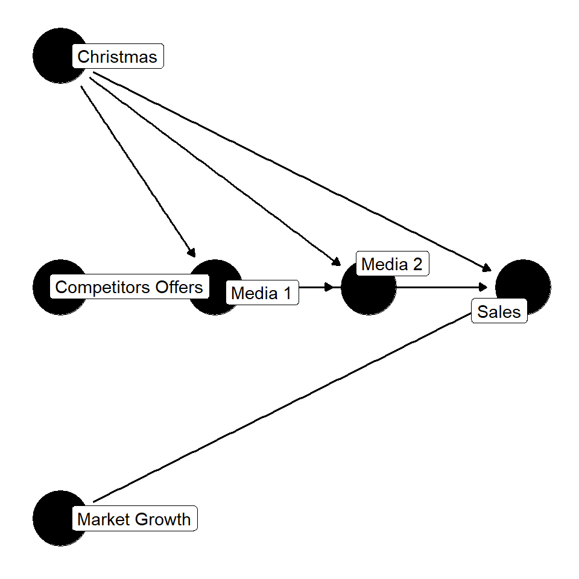

## Conceptos clave: Predicción vs Inferencia causal:

- Una correlación nos permite predecir con precisión un evento basado en otro, pero no implica que uno cause al otro.
- Ejemplo: Si sabemos que hay muchas ventas de helados, podemos predecir un aumento en ahogamientos, pero esto no significa que vender helados cause ahogamientos.

## Conceptos clave: Correlación ≠ Causalidad:

- Dos variables pueden estar asociadas debido a una tercera variable oculta.
- Introducir aquí la variable oculta: la temperatura media mensual, como una posible explicación detrás de ambas variables observadas.

## Conceptos clave: Concepto de *Confounder* (Confundidor):

- Variable que afecta simultáneamente tanto a la causa aparente como al efecto aparente.
- En nuestro caso, la temperatura actúa como un confundidor:
  - Más calor ➜ más ventas de helados.
  - Más calor ➜ más gente nadando, más riesgo de ahogamientos.

## Escalera causal de Judea Pearl

- **Nivel 1: Asociación** (*¿Qué ocurre?*): Correlaciones observadas, como entre helados y ahogamientos.
- **Nivel 2: Intervención** (*¿Qué ocurre si hacemos algo?*): Evaluamos qué sucede al intervenir activamente, por ejemplo, prohibiendo la venta de helados para ver si cambian las muertes por ahogamiento.
- **Nivel 3: Contrafactual** (*¿Qué habría pasado si hubiera sido diferente?*): Pensamos en escenarios alternativos, como cuántas muertes habrían ocurrido si la temperatura hubiera sido diferente.

Este marco ayuda a distinguir claramente entre **predicción (asociación)** e **inferencia causal (intervención y contrafactual)**.

## Conclusiones clave del caso

- No toda correlación implica causalidad.
- Es esencial identificar y ajustar confundidores para inferir relaciones causales.
- La inferencia causal requiere un nivel de análisis más profundo que la mera predicción basada en correlaciones.

## Otro

# DAGs y Estructuras Causales

## *Fork* - El *confounder* de toda la vida

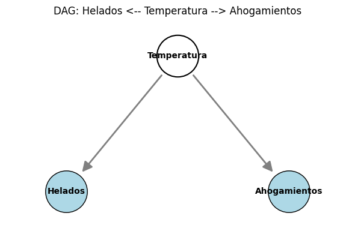

$X \leftarrow Z \rightarrow Y$

NOTEBOOK

- Si no hacemos nada, $Z$ está “abierta”: $Y$ puede “escuchar” a $X$ debido a la influencia común de $Z$: es una asociación espuria, no causal.
- Cuando controlamos por $Z$, la “cerramos”: eliminamos la asociación espuria entre $X$ e $Y$.

## *Chain* - La *mediación*

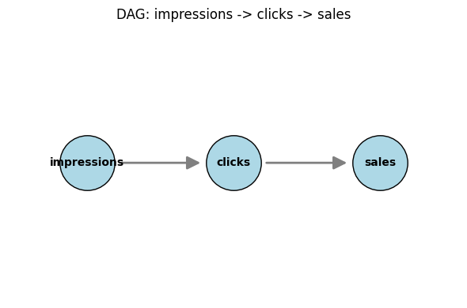

$X \rightarrow Z \rightarrow Y$

NOTEBOOK

- Si no hacemos nada, $Z$ está “abierta”: $Y$ puede “escuchar” a $X$, que es su causa indirecta a través de $Z$.
- Cuando controlamos por $Z$, la “cerramos”: eliminamos la asociación causal indirecta entre $X$ e $Y$.

## *Collider*

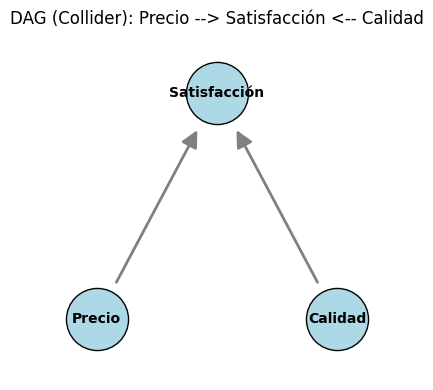

$X \rightarrow Z \leftarrow Y$

NOTEBOOK

- Si no hacemos nada, $Z$ está “cerrada”: $X$ y $Y$ son independientes, no hay asociación entre ellos.
- Si controlamos por $Z$, la “abrimos”: $X$ y $Y$ pueden “escucharse”: se crea una relación espuria, no causal.

## Independencia condicional

- *Confounder* $Z$: $X \leftarrow Z \rightarrow Y$
  - $X \not\perp Y$, $X \perp Y | Z$
- *Chain* $Z$: $X \rightarrow Z \rightarrow Y$
  - $X \not\perp Y$, $X \perp Y | Z$
- *Collider* $Z$: $X \rightarrow Z \leftarrow Y$
  - $X \perp Y$, $X \not\perp Y | Z$

# Dagitty

## Un ejemplo ¿más complejo?

- ¿Qué tengo que hacer si quiero identificar el efecto causal de $X$ sobre $Y$?
- [DAGitty](https://www.dagitty.net/): herramienta para crear y analizar gráficos acíclicos dirigidos (DAGs) que representan relaciones causales.

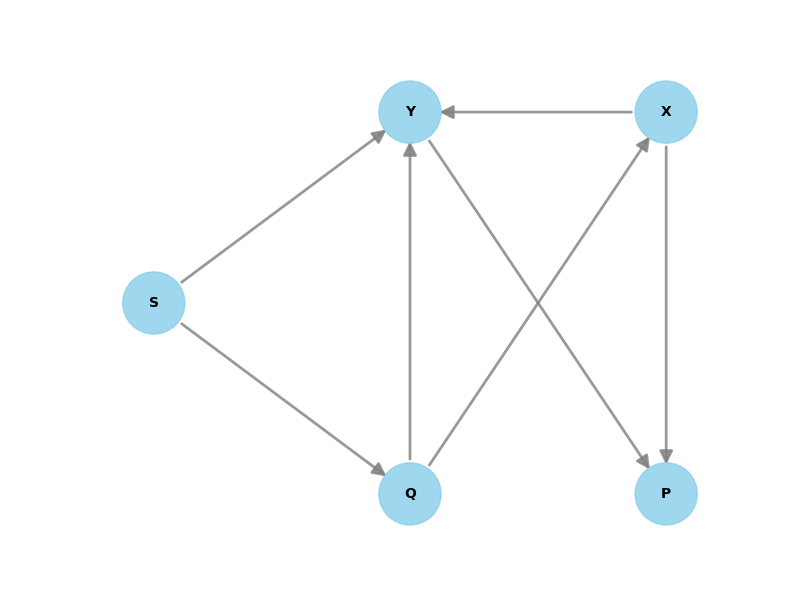

## Otros criterios

- **Backdoor criterion**
- **Frontdoor criterion**
- **Instrumental variable**

## Efectos directos e indirectos

- **Efecto total**: efecto de $X$ sobre $Y$.
- **Efecto directo**: efecto de $X$ sobre $Y$ que no pasa por $Z$.
- **Efecto indirecto**: efecto de $X$ sobre $Y$ que pasa por $Z$.

Notebook

# El caso de la fuga de clientes

## En R (Dagitty)

- Librería [dagitty](https://cran.r-project.org/web/packages/dagitty/index.html)
  - [Página oficial](https://www.dagitty.net/)

Notebook

## En python (doWhy, econML)

1. Pregunta inicial
2. Estimando
3. Estimador
4. Esticmación
5. Refutación

Notebook

# Go beyond

- Causal discovery